# E.Sun Data First Peek

## Datasets

- ETAB
- Call Center Inbound

## Data Cleaning

- Change encoding from cp950 to UTF-8
- Trim white-space
- Rename columns

## ETAB

## ETAB

- Currently is counted by tickets number (not exactly the amount of people)
- 1655 clerks among 136 branches
- The columns in ETAB (cleaned):

```
##  [1] "brh"        "sale.no"    "tkt.no"     "counter"    "clerk.card"
##  [6] "sta.tm"     "end.tm"     "serv.sec"   "tm.blk"     "wait.sec"
## [11] "wait.num"   "cu.grp"     "proc.dt"    "in.dtm"     "in.dt"
```

## Tickets by Date

- Shown only working days, not holidays

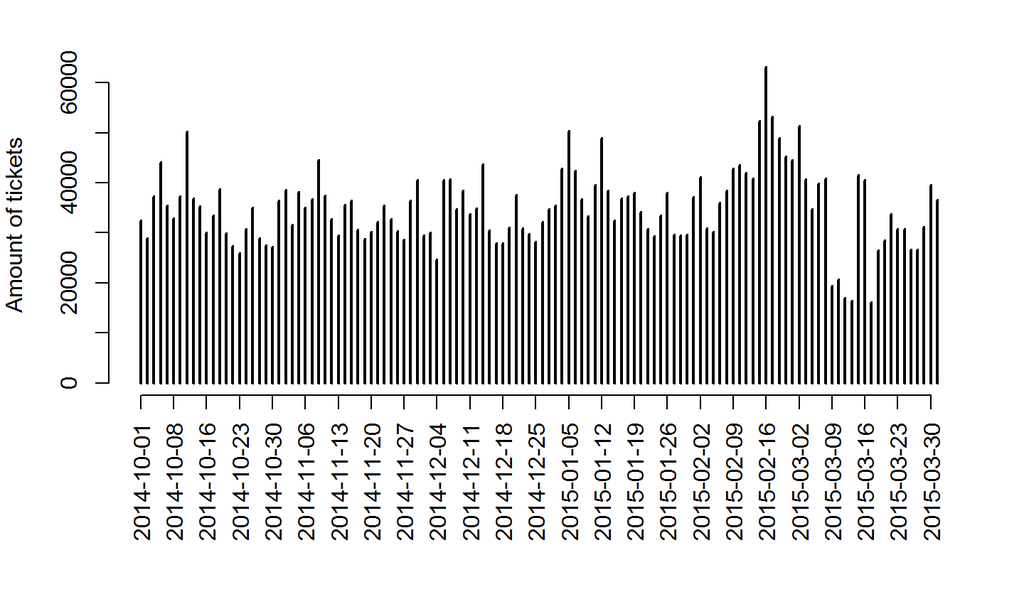

## Average Tickets by Weekdays

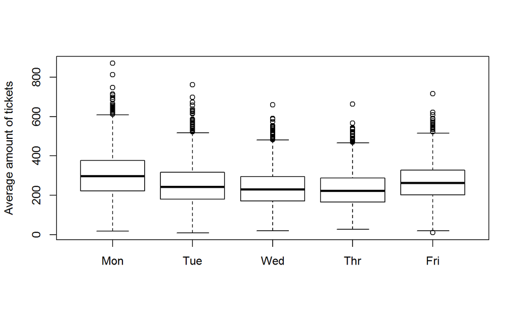

## Total Tickets Every Half-hour

- Time blocks (0-48) were transformed to (0-24)

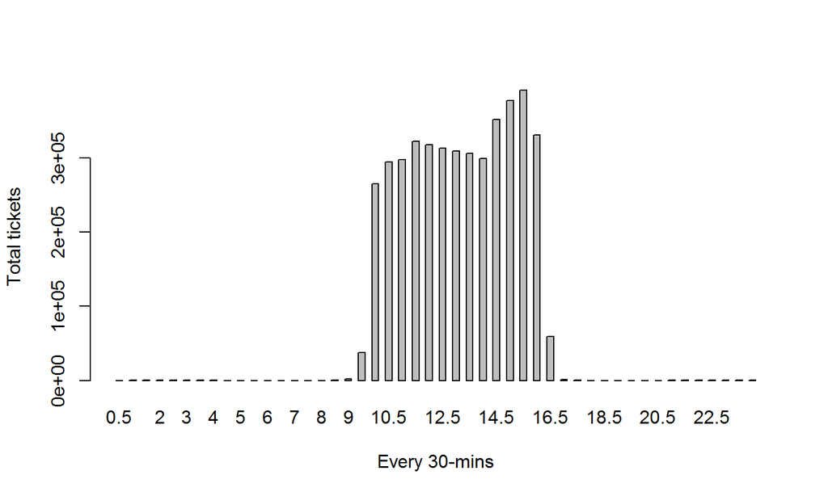

## Total Tickets Every Half-hour

- It seemed the time stamps were contaminated
- Need further examination

```
##    0.5      1    1.5      2    2.5      3    3.5      4    4.5      5
##      6    228    236    286    289    282    247    120     39     35
##    5.5      6    6.5      7    7.5      8    8.5      9    9.5     10
##     42     38     58     41     20     11    491   1740  37216 264702
##   10.5     11   11.5     12   12.5     13   13.5     14   14.5     15
## 294526 297022 321995 317166 312939 309288 305575 298888 351445 376913
##   15.5     16   16.5     17   17.5     18   18.5     19   19.5     20
## 390944 330261  59314   1010     85     41     14      3      1      4
##   20.5     21   21.5     22   22.5     23   23.5     24
##      1    178    149    138    124    133    120    101
```

## Daily Tickets of Branches (Rank)

```
##       brh     brh.name   avg.tkt    sd.tkt
##   1: 0440     竹南分行 492.20492 109.52263
##   2: 0509   東嘉義分行 453.47541  86.79093
##   3: 0071     嘉義分行 432.48361  83.02825
##   4: 0288     大墩分行 408.89344  87.52037
##   5: 0130     中壢分行 403.92623  93.11560
##  ---
## 132: 1399     烏日分行 116.30833  34.63223
## 133: 1344     竹科分行 112.37705  29.47764
## 134: 0587 新板特區分行 104.41803  27.82526
## 135: 1182     南港分行  97.95902  27.59458
## 136: 1229     信義分行  97.78689  26.04803
```

Summary:

```
##    Min. 1st Qu.  Median    Mean 3rd Qu.    Max.
##   97.79  201.20  256.70  258.00  314.80  492.20
```

## Ticket No. in Total

- The "skipped ticket" is still included

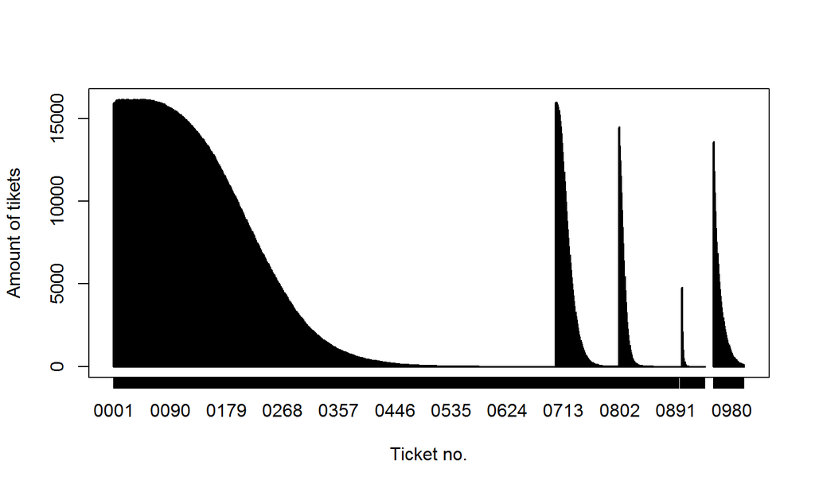

## Customer Types

- Tkts of each customer groups:

```
##
##    GRP1    GRP2    GRP3    GRP4    GRP5
## 3645115  358790  126480    8905  135215
```

- Tkts of each catogories:

```
##
##       A       B       C
## 3789235  358790  126480
```

## Waiting and Service Time

```r
summary(etab$wait.sec)
```

```
##    Min. 1st Qu.  Median    Mean 3rd Qu.    Max.
##  -468.0    43.0   166.0   308.9   419.0 74120.0
```

```r
summary(etab$serv.sec)
```

```
##    Min. 1st Qu.  Median    Mean 3rd Qu.    Max.
##  -545.0     5.0   124.0   302.1   347.0 23500.0
```

## Service Time

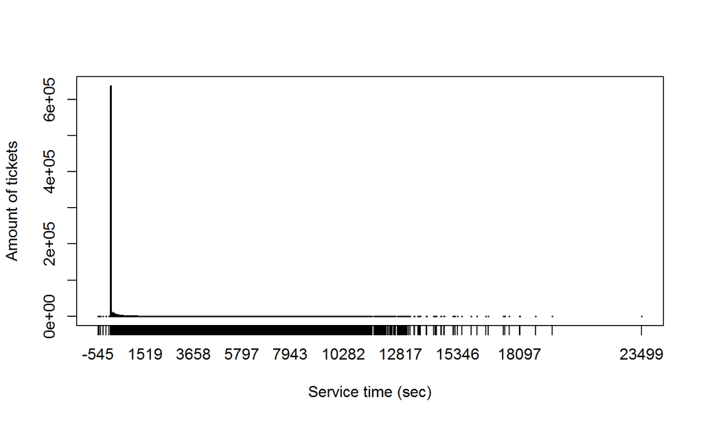

## Service Time

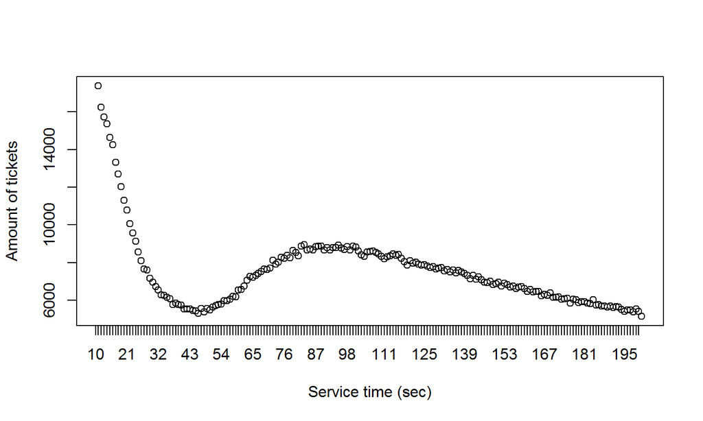

## Waiting Time

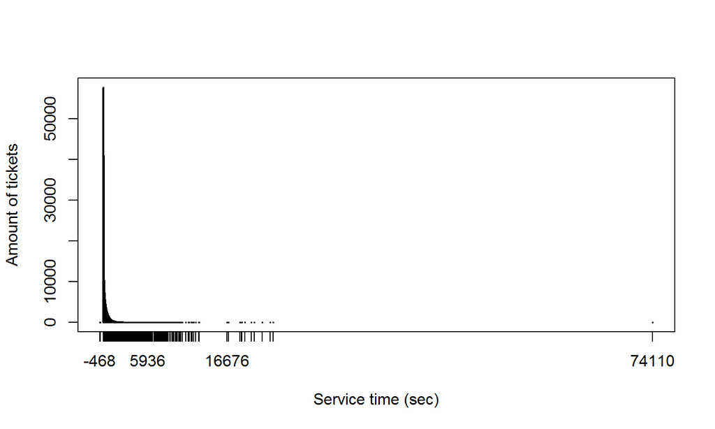

## Waiting Time

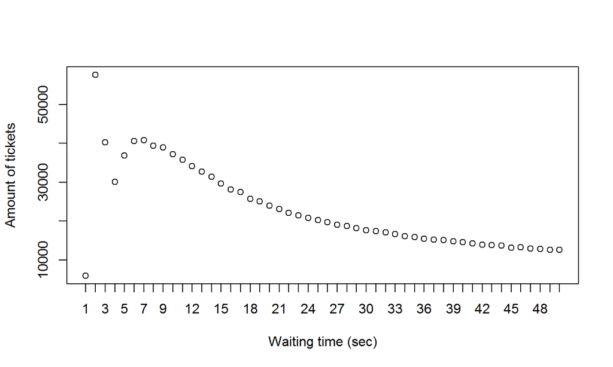

## Later-on Analysis

- check the contanminated time span
- filter out the skipped tkts
- customer/datetime/branch/clerk
- …and so on

## Call Center Inbound

## Call Center Inbound

- 796264 customers called
- With 344 operators
- The columns in call-center-inbound (cleaned):

```
##  [1] "act.id"     "seq.no"     "cu.id"      "cu.id.md5"  "call.dt"
##  [6] "opr.id"     "opr.id.md5" "rsn.id1"    "rsn.1"      "rsn.id2"
## [11] "rsn.2"      "rsn.id3"    "rsn.3"      "call.type"  "type.descr"
```

## Calls by Date

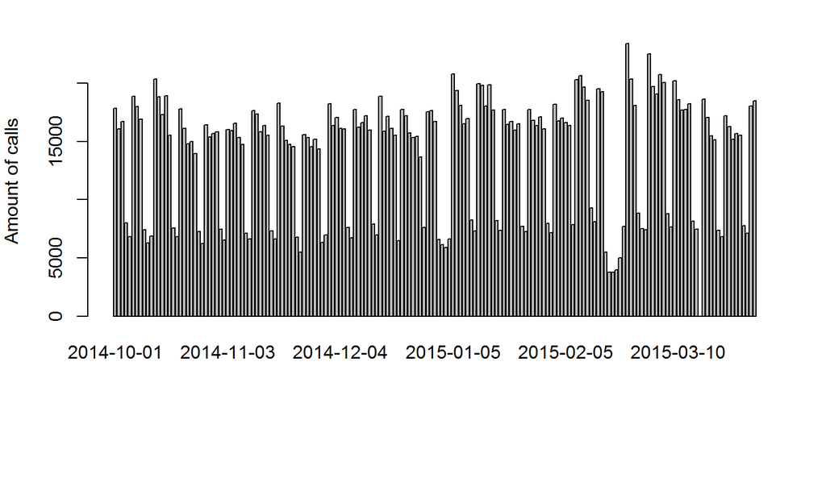

## Average Calls by Weekdays

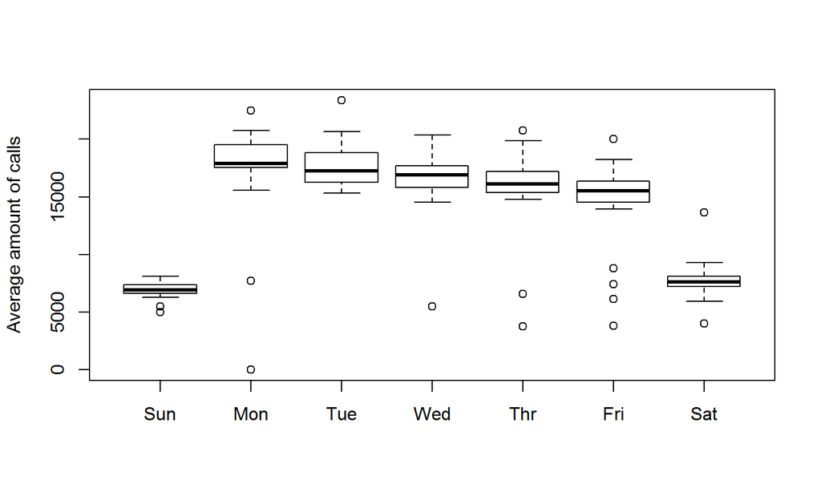

## Call-in Reasons (Rank)

- In 37 catogories:

```
##
##      A     AC     AD     AE     AF     AH     AM     AN     AR     AT
##  51991  52612 209421 108800   9111  14059   1249  24353   6919  62648
##     AU     AW     AX     AY     AZ      B     BA     BB     BC      C
##     18     25   2608  47902  21900  24077  11083  17434   1671  14824
##     DA     EA      F      G      H      I      J      K      L      M
##     39    118 120979   1333    907 154124   6108   1729 107409 666859
##      N      O      P      Q      R      S      Y
## 417379  53834 114364  83577  17523  12583   5097
```

## Call-in Reasons (Rank)

- M: 信用卡帳務問題
- N: 信用卡製卡/掛失/授權/使用詢問
- AD: 卡片附加優惠(保險/停車/貴賓室/道救)

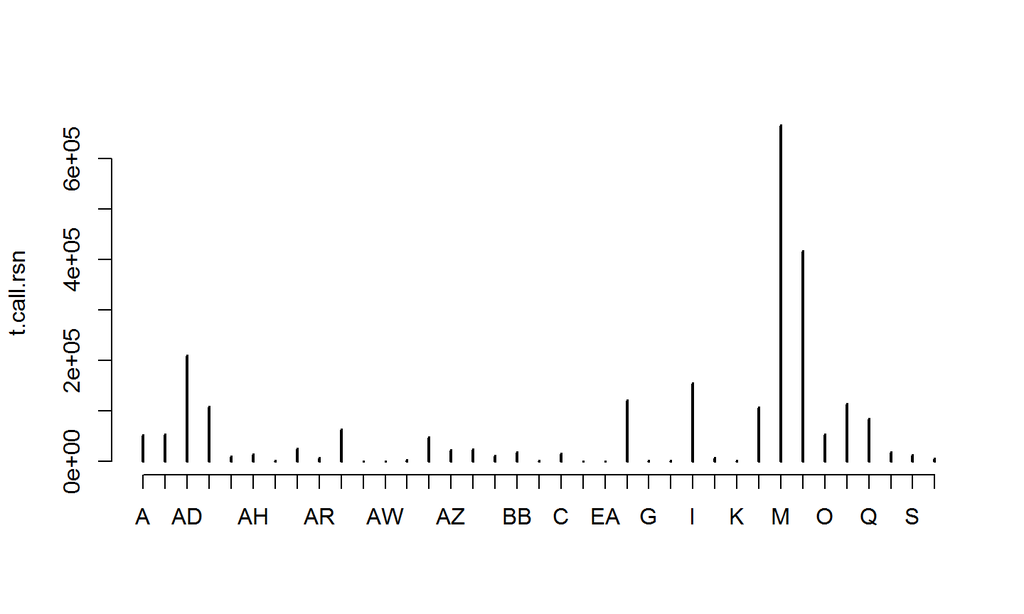

## Call-in Reasons (Rank)

- M: 信用卡帳務問題 **(帳單查詢、繳款查詢)**
- N: 信用卡製卡/掛失/授權/使用詢問 **(額度查詢)**
- AD: 卡片附加優惠(保險/停車/貴賓室/道救)

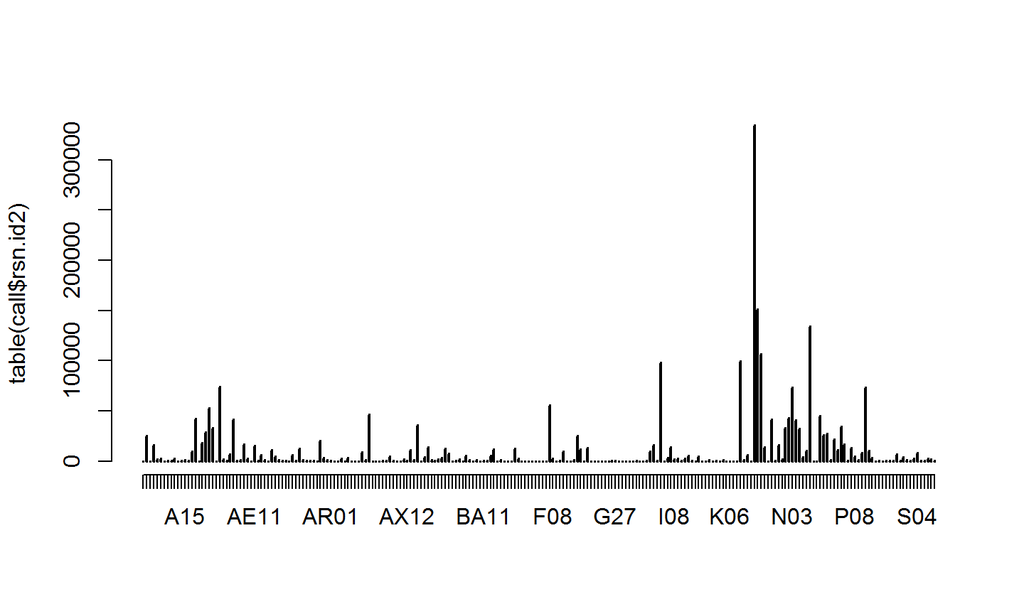

## Call type

```r
table(call$call.type)
```

```
##
##            AUTO   CMPLT     CSR   EMGCY   OABNK   OPBNK   OPERA   OPPOR
## 2425715      94      63       6      25      91    1293   15907     729
##   OPYEH   OUBNK   PRAIS   SUGGT   TRACA   TRACC   TRACD   TRACE
##      72      11      33      20       2       7      39    2560
```

## Later-on Analysis

- bind with customer type analysis
- cost analysis
- …and so on